# Projet : Modèle Linéaire Généralisé / Choix de Modèle - R

Marlène Chevalier

31/08/2019

# 1 Sujet : Pluie à Bâle

Il s’agit de proposer et valider un modèle qui permettra d’expliquer et de prédire la présence de pluie le jour suivant à Bâle. Pour ce faire, les données disponibles sont sous forme de 2 fichiers :

- un fichier d’entrainement *meteo.train.csv*
- un fichier test *meteo.test.csv*

Ces deux fichiers contiennent des données météorologiques quotidiennes enregistrées sur des journées entre juin 2010 et juin 2018 :

- Valeurs moyenne, minimale et maximale :
  - Température (°C),
  - Humidité relative (%),
  - Pression (hPa),
  - Nébulosité (%) : Nébulosité forte (ciel élevé : entre 7 et 13 km d’altitude) / Nébulosité moyenne (ciel moyen: entre 2 et 7km d’altitude) / Nébulosité faible (ciel bas : jusqu’à 2 km),
  - Vitesse (km/h) selon l’altitude(10m / 80m / altitude avec 900hPa),
  - Direction du vent (°) selon l’altitude(10m / 80m / altitude avec 900hPa),
  - Rafale de vent à 10 mètres (km/h)
- Valeur Totale :
  - Précipitations (mm),
  - Neige (cm),
  - Ensoleillement (minutes),
  - Rayonnement solaire (W/m²)

Le fichier d’entrainement contient, en plus, la colonne *pluie.demain* qui indique la prédiction de pluie pour le lendemain. Il s’agit de proposer une prediction *pluie.demain* qui sera à inclure dans le fichier test. Cette prédiction sera donc basée sur les conditions météorologiques de la veille.

# 2 Exploration des données

Le fichier metéo *entrainement* contient 1244 lignes et 47 colonnes.  
Le fichier metéo *test* contient 227 lignes et 46 colonnes.

## 2.1 Les précipitations mensuelles

A Bâle, les précipitations sont en moyenne plus abondantes entre mai et août. Les niveaux moyens sont néanmoins assez proches d’un mois sur l’autre ( entre 1mm et 2.8 mm *cf.graphe 1*) et les niveaux journaliers sont souvent loin de ces moyennes (dispersion importante *cf.graphe 2*).

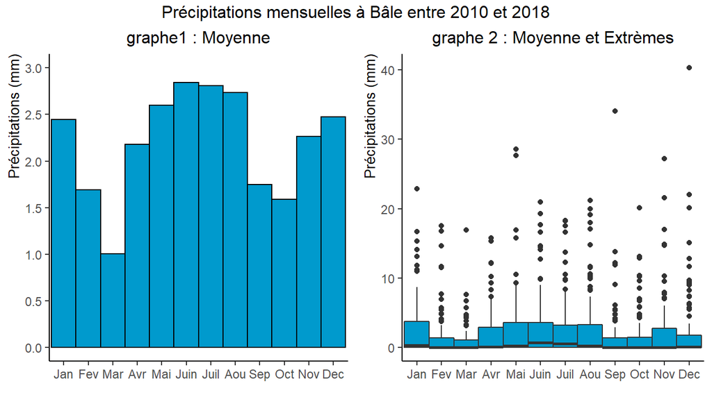

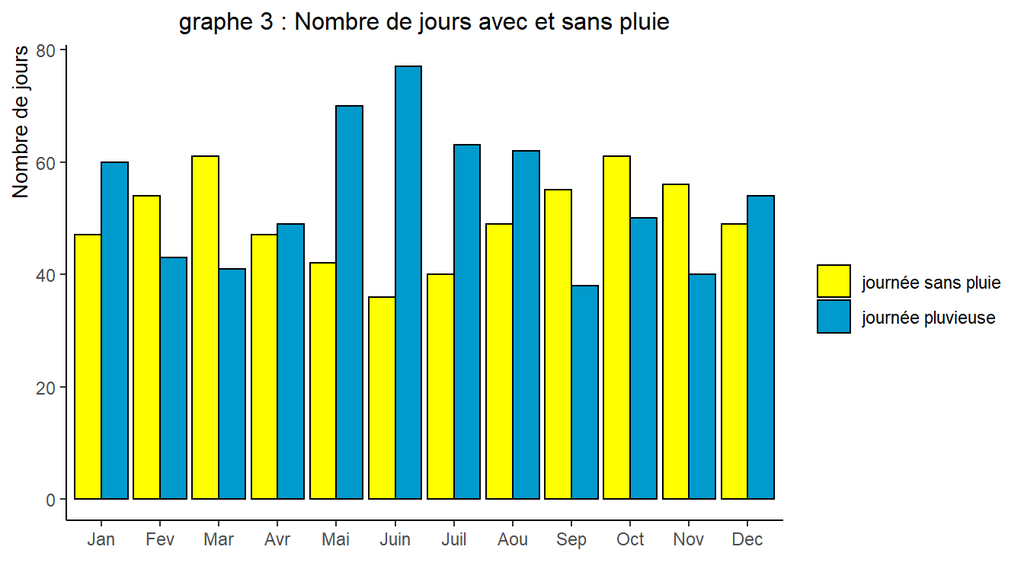

## 2.2 Les observations liées aux prévisions de précipitations

Examinons maintenant le comportement des variables météorologiques au regard de la prédiction qui a été faite pour le lendemain.

- La température du jour semble peu influencer les prévisions du lendemain (*cf. graphe 5* : le niveau médian de température est proche quelle que soit la prévision pour le lendemain). Le *graphe 4* ne montre pas non plus d’influence particulière de la température du jour sur la prévision du lendemain (répartition similaire des prévisions de journées pluvieuses ou non) Par contre lorsque le niveau de précipitation du jour est important, on aura tendance à prévoir de la pluie pour le lendemain (points bleus plus représentéés pour un niveau élévé de précipitations)
- Le taux d’humidité du jour ne semble pas non plus avoir une influence marquante sur les prévisions météo (*cf graphe 7* : le niveau médian d’humidité du jour est très légèrement plus élevé lorsque on prévoit de la pluie).
- **La pression athmosphérique du jour**, par contre, semble être un indicateur pour prévoir le temps du lendemain : en effet, on voit très clairement que le niveau médian est bas lorqu’on prévoit de la pluie pour le lendemain (*cf. graphe 9*).
- **La nébulosité du jour** semble aussi annoncer le temps du lendemain : plus elle est importante, plus on aura tendance à prévoir de la pluie pour le lendemain (*cf. graphe 11* : niveau médian de nébulosité plus fort lorsqu’on prévoit de la pluie).
- **La durée d’enseillement du jour** a également une influence sur les prévisions du lendemain : moins l’ensoleillement est important, plus on aura tendance à prévoir de la pluie pour le lendemain (*cf. graphe 13* : le niveau médian du temps d’ensoleillement ).
- **Les rafales de vent** ont également une influence sur les prévisions du lendemain (*cf. graphe 15* : le niveau médian des vitesses de rafale de vent est plus important lorsqu’on prévoit de la pluie).
- **La vitesse et la direction du vent** de la journée semblent impacter significativement les prévisions pour le lendemain (*cf. graphes 16 à 24*). Les vents du nord et d’ouest amènent des pluie plus abondantes que les vents du sud et d’est (*cf. graphes 16 à 18*). Les vents d’ouest quelque soit leur vitesse sont souvent signe de pluie en journée et conduit à prévoir une journée du lendemain pluvieuse (*cf. graphes 19 à 24*).

D’après ces observations graphiques, on a l’impression que la pression athmosphérique, la nébulosité, l’ensoleillement, les caractéristiques du vent d’une journée ont un impact sur la prévision météo pour le lendemain.

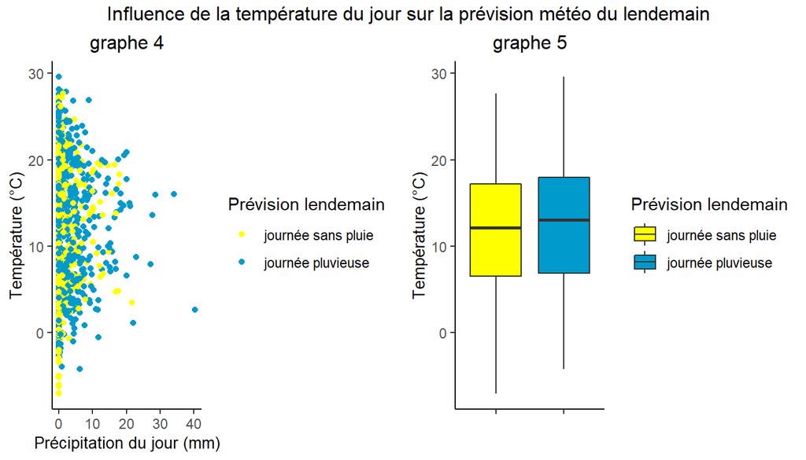

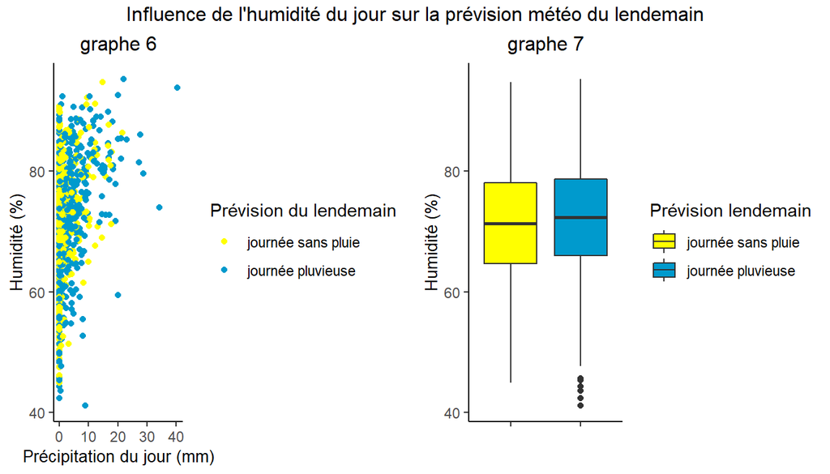

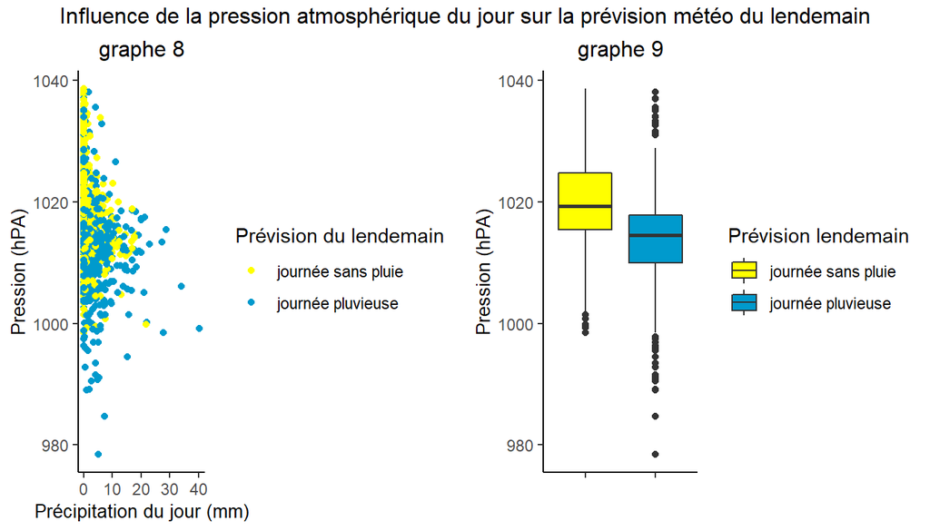

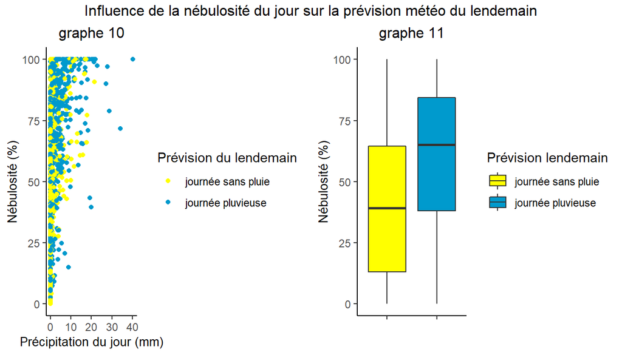

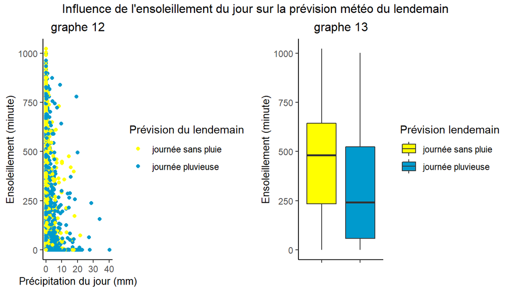

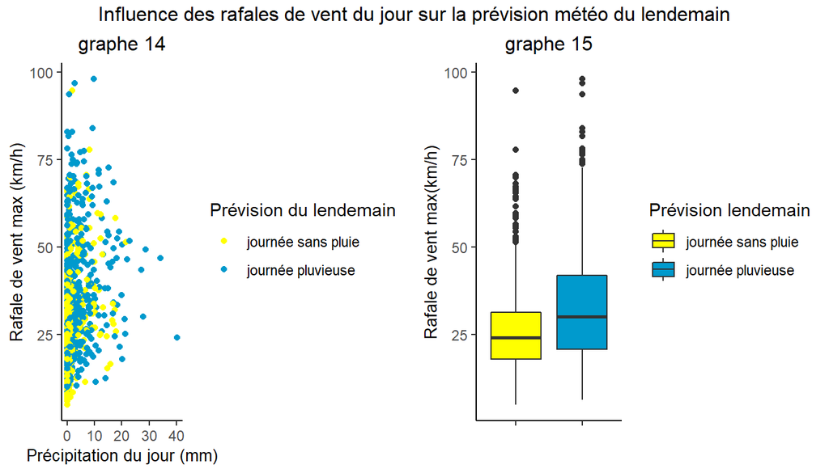

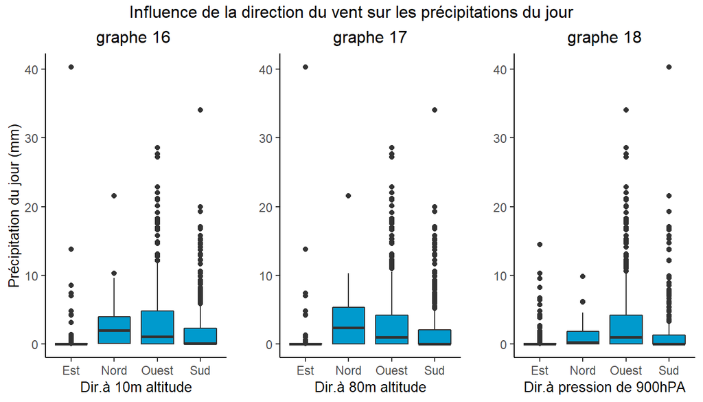

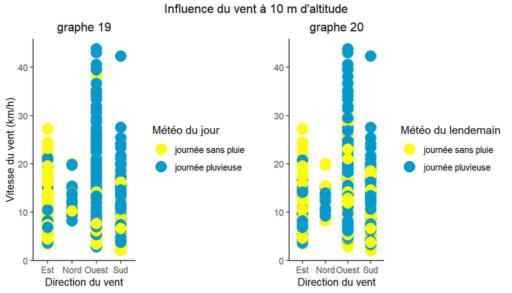

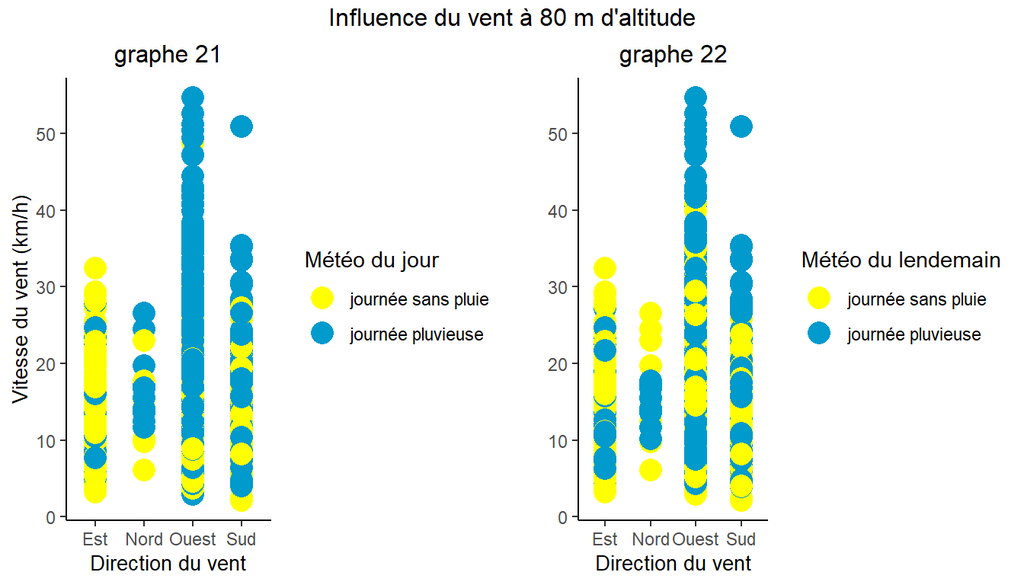

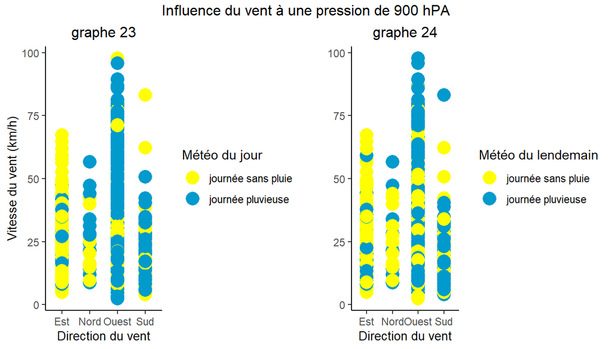

# 3 Choix du modèle

Il s’agit maintenant de trouver un modèle qui explique de façon satisfaisante la prévision “pluie.demain”. Nous avons à disposition 46 variables explicatives. Il est donc fastidieux de tester tous les modèles possibles. Essayons de vérifier quelques corrélations intuitives permettant de ne pas sélectionner des variables redondantes.

## 3.1 Vérification de corrélations

Testons les corrélations entre les variables de nébulosité, de vitesse de vent, de direction du vent.  
Il apparait des corrélations statistiquement significatives (p-value de cor.test<5%) entre les variables de direction du vent (entre 10m, 80m d’altitude et sous 900HPA), de vitesse du vent (entre 10m, 80m d’altitude, sous 900HPA), de rafale de vent, de nébulosité (totale / forte / médium / faible).

**Coefficients de corrélation** :

| Direction_Vent | a_10m | a_80m | sous_900Hpa |
| --- | --- | --- | --- |
| 10m | 1.00 | 0.97 | 0.50 |
| 80m | 0.97 | 1.00 | 0.57 |
| 900HPa | 0.50 | 0.57 | 1.00 |

| Vitesse_Vent | a_10m | a_80m | sous_900HPa |
| --- | --- | --- | --- |
| 10m | 1.00 | 0.98 | 0.8 |
| 80m | 0.98 | 1.00 | 0.8 |
| 900HPa | 0.80 | 0.80 | 1.0 |

| Rafale_Vent | min | moy | max |
| --- | --- | --- | --- |
| min | 1.00 | 0.82 | 0.58 |
| moy | 0.82 | 1.00 | 0.88 |
| max | 0.58 | 0.88 | 1.00 |

| Nebulosite_Moyenne | Totale | Forte | Medium | Faible |
| --- | --- | --- | --- | --- |
| Totale | 1.00 | 0.51 | 0.78 | 0.90 |
| Forte | 0.51 | 1.00 | 0.71 | 0.25 |
| Medium | 0.78 | 0.71 | 1.00 | 0.56 |
| Faible | 0.90 | 0.25 | 0.56 | 1.00 |

Des corrélations fortes (coef de corrélation proche de 1 ) existent entre :

- les directions du vent à 10m et à 80m
- les vitesses de vent à 10m, à 80m et sous 900HPa
- les rafales de vent minimum et moyenne
- les nébulosités totale, faible et médium
- les nébulosités forte et médium

## 3.2 Méthode “exhaustive”

Dans un premier temps, utilisons une méthode de choix de modèle “manuelle” en sélectionnant les variables explicatives semblant pertinentes sur la base des influences et correlations observées. Les critères CP Mallows, BIC permettent d’identifier ds variables explicatives pertinentes (variables avec CP Mallows minimal / BIC minimal).

Illustration de la démarche en testant plusieurs modèles.

**Modèle 1** : 10 variables explicatives (choisies à partir des corrélations et influences observées précédemment).

- pression moyenne,
- précipitation,
- nébulosités totale et forte,
- vitesse moyenne du vent à 10m,
- direction du vent à 10m et sous 900hPa,
- ensoleillement
- rafales de vent minimum et maximum

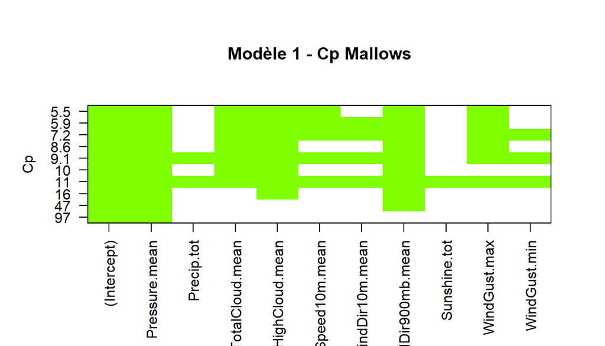

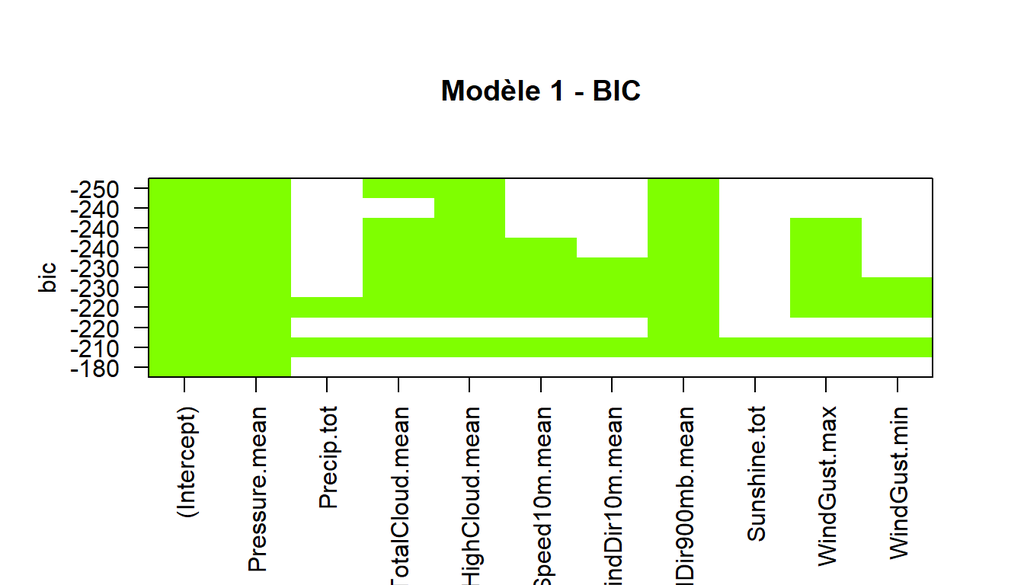

**Résultat Modèle 1 :**  
Les précipitations et l’ensoleillement semblent être des variables peu pertinentes pour expliquer les prévisions météo du lendemain.

**Modèle 2** : 8 variables explicatives : remplacement de la variable vitesse de vent à 10m altitude par celle sous 900hPA et suppresion des variables ensoleillement et précipitation.

- pression moyenne,
- nébulosités totale et forte,
- vitesse maximum du vent sous 900hPA,
- direction du vent à 10m et sous 900hPA,
- rafales de vent max et min

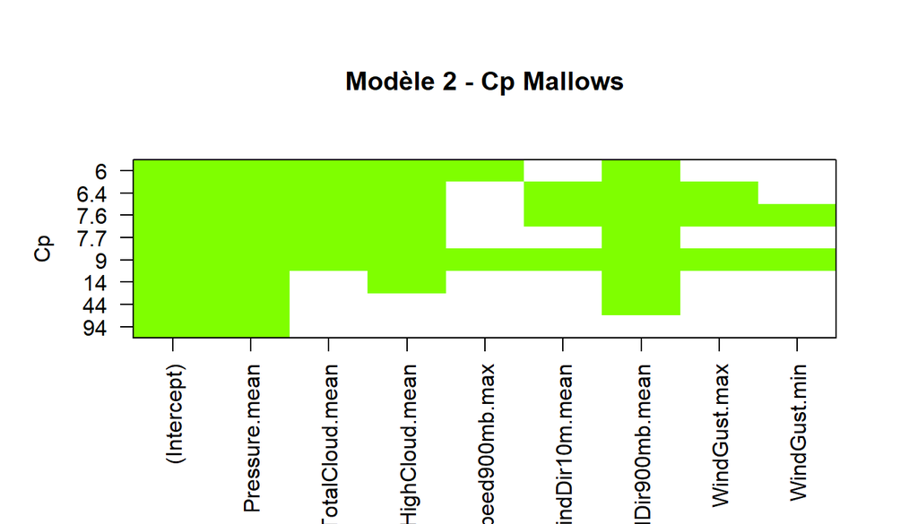

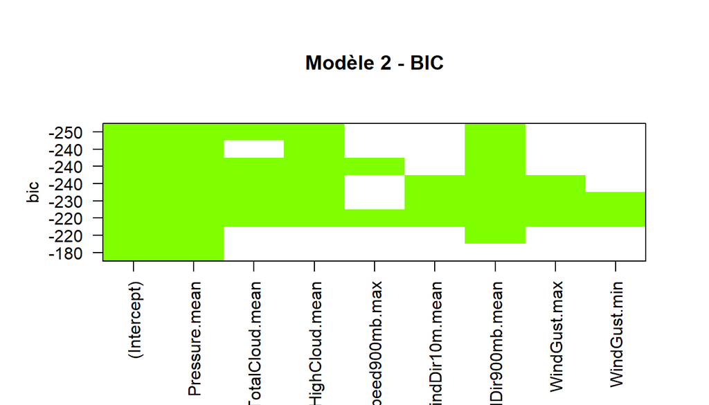

**Résultat Modèle 2** :  
Après observation des résultats sur les modèles 1 et 2, on constate que les 4 variables les plus pertinentes sont la pression atmosphérique, les nébulosités totale et forte, la direction du vent sous 900HPa.

**Modèle 3** : 4 variables explicatives (modèle minimal : selection des variables min BIC et AIC)

- pression moyenne,
- nébulosité totale et forte,
- direction du vent sous 900hPA

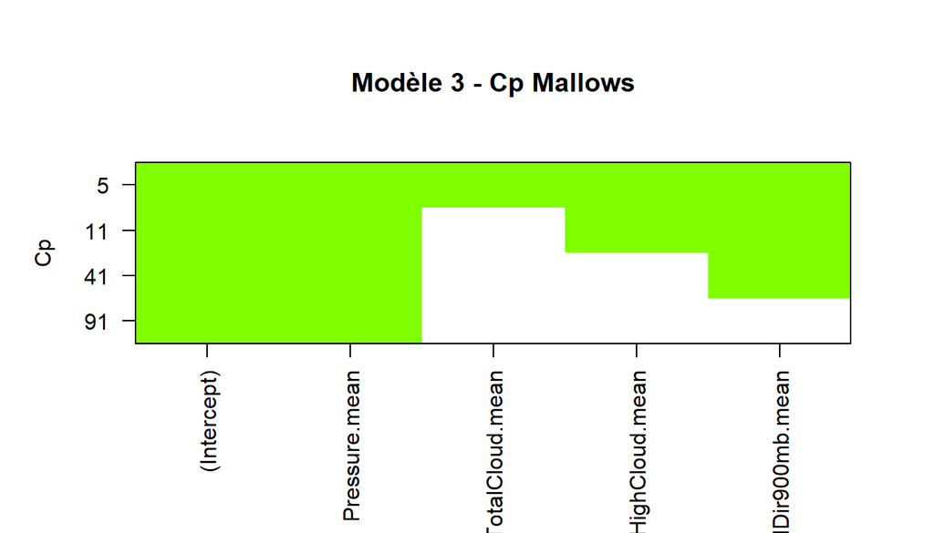

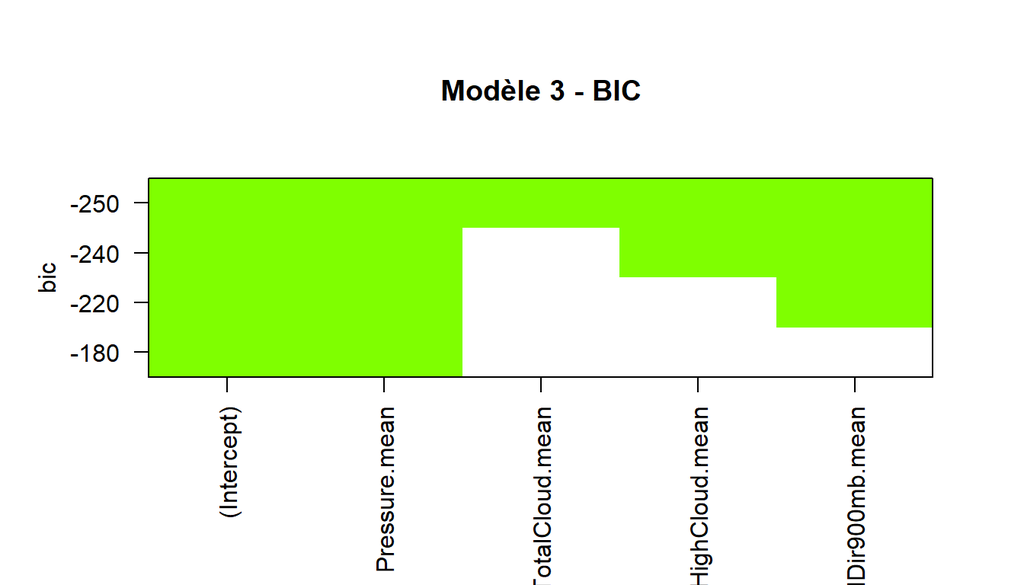

**Résultat Modèle 3** :  
Les 4 variables du modèle 3 confirment leur pertinence à expliquer la météo du lendemain.  
Testons un modèle plus complet en introduisant le rayonnement solaire au modèle 2.

**Modèle 4** : 9 variables explicatives : modèle 2 +rayonnement solaire

- pression moyenne,
- rayonnement solaire,
- nébulosités totale et forte,
- vitesse maximum du vent sous 900hPA,
- direction du vent à 10m et sous 900hPA,
- rafales de vent max et min

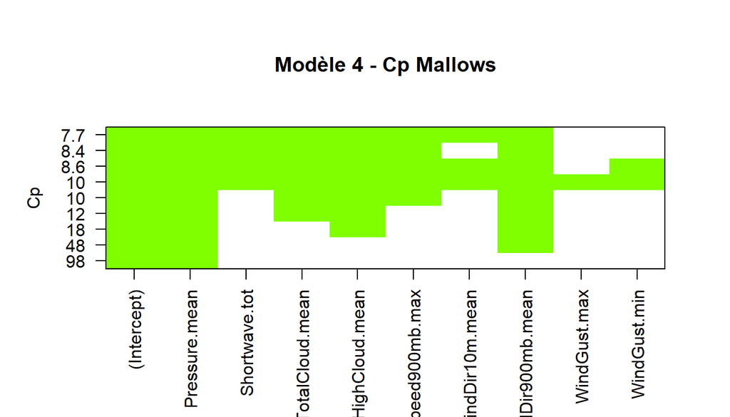

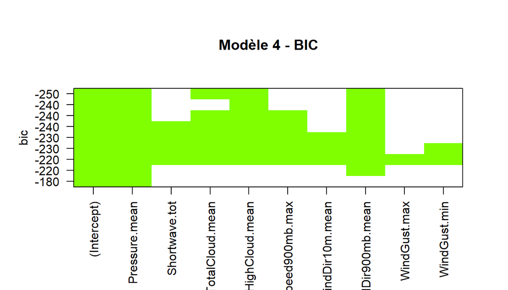

Testons un modèle plus complet en incluant le niveau de chite de neige et l’humidité moyenne.

**Modèle 5** : 11 variables explicatives : modèle 4 + neige + humidité moyenne

- pression moyenne,
- rayonnement solaire,
- nébulosités totale et forte,
- vitesse maximum du vent sous 900hPA,
- direction du vent à 10m et sous 900hPA,
- rafales de vent max et min
- neige
- humidité moyenne

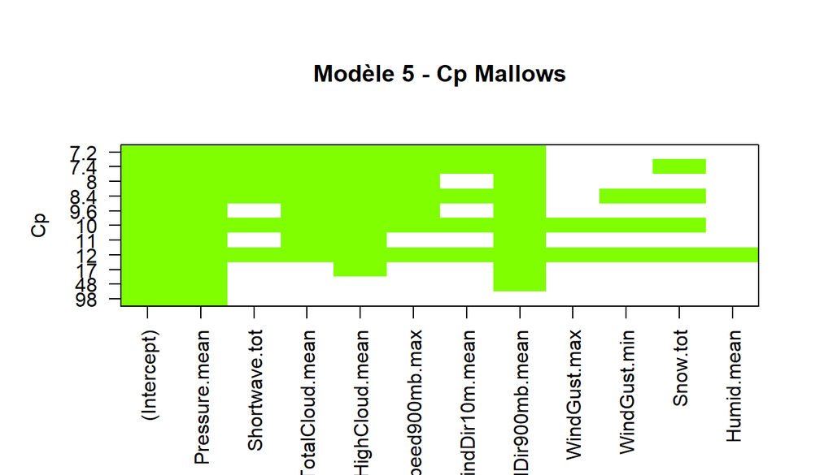

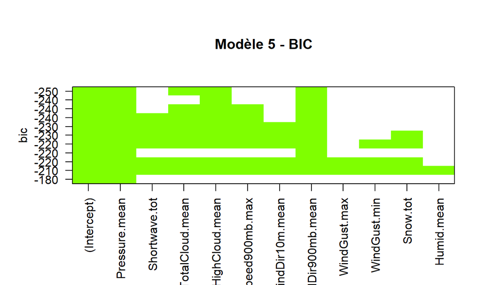

## 3.3 Méthode “progressive”

Dans cette étape, pour choisir les variables explicatives du modèle, nous allons utiliser une des méthodes pas à pas : la méthode progressive. Elle consiste, à chaque itération, à ajouter au modèle une variable explicative (celle avec le plus petit AIC et tel que cet AIC soit inférieur à l’AIC du modèle nul) et à remettre en cause les variables intégrées lors des itérations précédentes.

Le modèle utilisé sera le **modèle logistique** : en effet, il permet d’expliquer une variable binaire (présence de pluie ou non demain) en fonction de variables explicatives sélectionnées.  
En R : *glm ( pluie.demain ~ variables explicatives, family = binomial )*

Commençons par tester le modèle 1.

**Modèle 1** : 10 variables explicatives proposées

**Déroulement de la sélection de variables explicatives** :

*Etape 1* : le critère AIC de la variable pression atmosphérique est le plus bas et est inférieur à l’AIC de référence (none).  
-> choix de la variable : **pression atmosphérique**

*Etape 2* : le critère AIC de la variable direction du vent sous 900HPa est le plus bas et est inférieur à l’AIC de référence (none).  
-> choix de la variable : **direction du vent sous 900HPa**

*Etape 3* :  
-> choix de la variable : **nébulosité forte**

*Etape 4* : -> choix de la variable : **nébulosité totale**

*Etape 5* : -> choix de la variable **rafale maximum**

*Etape 6* : -> choix de la variable **vitesse du vent à 10m**

*Etape 7* : les AIC des variables restantes sont supérieurs à AIC de référence  
-> **sélection de variables explicatives est terminée**

**Résultat Modèle 1** : 6 variables sont sélectionnées = *Modèle 1 réduit*

- pression atmosphérique,
- direction du vent sous 900hPA,
- nébulosités totale et forte
- rafale de vent max
- vitesse du vent à 10m

```
## Start:  AIC=1726.52
## pluie.demain.bin ~ 1
##
##                     Df Deviance    AIC
## + Pressure.mean      1   1527.4 1531.4
## + TotalCloud.mean    1   1614.7 1618.7
## + HighCloud.mean     1   1624.4 1628.4
## + Sunshine.tot       1   1646.9 1650.9
## + WindDir900mb.mean  1   1649.8 1653.8
## + WindGust.max       1   1652.9 1656.9
## + Precip.tot         1   1655.8 1659.8
## + WindSpeed10m.mean  1   1690.0 1694.0
## + WindGust.min       1   1705.1 1709.1
## + WindDir10m.mean    1   1706.8 1710.8
## <none>                   1724.5 1726.5
##
## Step:  AIC=1531.43
## pluie.demain.bin ~ Pressure.mean
##
##                     Df Deviance    AIC
## + WindDir900mb.mean  1   1480.9 1486.9
## + HighCloud.mean     1   1486.0 1492.0
## + TotalCloud.mean    1   1490.4 1496.4
## + Sunshine.tot       1   1495.9 1501.9
## + WindGust.max       1   1505.6 1511.6
## + Precip.tot         1   1511.2 1517.2
## + WindDir10m.mean    1   1518.1 1524.1
## + WindSpeed10m.mean  1   1521.9 1527.9
## + WindGust.min       1   1522.8 1528.8
## <none>                   1527.4 1531.4
## - Pressure.mean      1   1724.5 1726.5
##
## Step:  AIC=1486.87
## pluie.demain.bin ~ Pressure.mean + WindDir900mb.mean
##
##                     Df Deviance    AIC
## + HighCloud.mean     1   1451.4 1459.4
## + TotalCloud.mean    1   1459.8 1467.8
## + Sunshine.tot       1   1461.9 1469.9
## + WindGust.max       1   1471.2 1479.2
```

[output cut: 59 more lines]

```
## pluie.demain.bin ~ Pressure.mean + WindDir900mb.mean + HighCloud.mean +
##     TotalCloud.mean + WindGust.max + WindSpeed10m.mean
##
##                     Df Deviance    AIC
## <none>                   1436.9 1450.9
## + WindDir10m.mean    1   1435.3 1451.3
## + WindGust.min       1   1436.4 1452.4
## + Precip.tot         1   1436.9 1452.9
## + Sunshine.tot       1   1436.9 1452.9
## - TotalCloud.mean    1   1441.8 1453.8
## - WindSpeed10m.mean  1   1441.9 1453.9
## - WindGust.max       1   1445.1 1457.1
## - HighCloud.mean     1   1448.3 1460.3
## - WindDir900mb.mean  1   1461.9 1473.9
## - Pressure.mean      1   1533.4 1545.4
```

```
##
## Call:  glm(formula = pluie.demain.bin ~ Pressure.mean + WindDir900mb.mean +
##     HighCloud.mean + TotalCloud.mean + WindGust.max + WindSpeed10m.mean,
##     family = binomial, data = d.train)
##
## Coefficients:
##       (Intercept)      Pressure.mean  WindDir900mb.mean
##         91.433917          -0.091575           0.004605
##    HighCloud.mean    TotalCloud.mean       WindGust.max
##          0.012417           0.005701           0.021539
## WindSpeed10m.mean
##         -0.040301
##
## Degrees of Freedom: 1243 Total (i.e. Null);  1237 Residual
## Null Deviance:       1725
## Residual Deviance: 1437  AIC: 1451
```

**Modèle 2** : 8 variables explicatives proposées

**Résultat Modèle 2** : 5 variables sont selectionnées = *Modèle 2 réduit*

- pression atmosphérique,
- direction du vent sous 900hPA,
- nébulosités totale et forte,
- vitesse du vent à 900HPa

**Modèle 3** : 4 variables explicatives proposées

**Résultat Modèle 3** : Toutes les variables sont sélectionnées.

- pression atmosphérique,
- direction du vent sous 900hPA,
- nébulosités totale et forte

**Modèle 4** : 9 variables explicatives proposées

**Résultat Modèle 4** : 7 variables sont selectionnées = *Modèle 4 réduit*

- pression atmosphérique,
- direction du vent sous 900hPA et à 10m,
- nébulosités totale et forte,
- vitesse du vent à 900HPa,
- rayonnement solaire

**Modèle 5** : 11 variables explicatives proposées

**Résultat Modèle 5** : 8 variables sont selectionnées = *Modèle 5 réduit*

**Les 5 modèles sont réduits aux variables selectionnées dans la méthode progressive.**

**AIC et déviance des modèles réduits**

| Modele | AIC | Deviance | Df |
| --- | --- | --- | --- |
| Modèle nul | 1727 | 1725 | 1243 |
| Modèle 1 réduit | 1451 | 1437 | 1237 |
| Modèle 2 réduit | 1454 | 1442 | 1238 |
| Modèle 3 | 1455 | 1445 | 1239 |
| Modèle 4 réduit | 1452 | 1436 | 1236 |
| Modèle 5 réduit | 1450 | 1432 | 1235 |

**Résultat de la méthode progressive** :  
Le meilleur modèle est le 5 (le critère AIC le plus bas). Les modèles 1 et 4 sont également de bons modèles : ils affichent un critère AIC légèrement supérieur.

# 4 Validation du modèle

## 4.1 Test de la déviance

Il s’agit de comparer :

- le modèle choisi au modèle nul (sans covariable) sur le critère de la déviance.  
  Si la p-valeur du test de chi2 (D0 : déviance modèle nul - Dk : déviance modèle choisi, dfD0 - dfDk ) < 5%, on rejette le modèle nul.
- le modèle choisi au modèle saturé (avec l’ensemble des covariables) sur le critère de la déviance.  
  Si la p-valeur du test de chi2 (Dk : déviance modèle choisi, dfDk ) < 5%, on rejette le modèle choisi.

| Modele | pvalue.Deviance.nulle | pvalue.Deviance.saturee |
| --- | --- | --- |
| Modèle 1 réduit | 0 | 1e-04 |
| Modèle 2 réduit | 0 | 0e+00 |
| Modèle 3 | 0 | 0e+00 |
| Modèle 4 réduit | 0 | 1e-04 |
| Modèle 5 réduit | 0 | 1e-04 |

**Résultat du test de déviance** :  
Les modèles testés sont meilleurs que le modèle nul (sans covariable) mais moins bons que le modèle saturé (46 variables).

## 4.2 Test anova

Il s’agit de comparer 2 modèles imbriqués et de déterminer le “meilleur” des 2 modèles à partir de la p_value du test. si la p-value est < au seuil (ex: 5%) alors le modèle avec le plus de covariables est le meilleur.

- Modèle 1 vs Modèle 3 :  
  p-valeur < 5%, le meilleur modèle est celui avec le plus de covariables : le modèle 1

```
## Analysis of Deviance Table
##
## Model 1: pluie.demain.bin ~ Pressure.mean + TotalCloud.mean + HighCloud.mean +
##     WindSpeed10m.mean + WindDir900mb.mean + WindGust.max
## Model 2: pluie.demain.bin ~ Pressure.mean + TotalCloud.mean + HighCloud.mean +
##     WindDir900mb.mean
##   Resid. Df Resid. Dev Df Deviance Pr(>Chi)
## 1      1237     1436.9
## 2      1239     1445.1 -2  -8.2164  0.01644 *
## ---
## Signif. codes:  0 '***' 0.001 '**' 0.01 '*' 0.05 '.' 0.1 ' ' 1
```

- Modèle 3 vs Modèle 4 :  
  p-valeur < 5%, le meilleur modèle est celui avec le plus de covariables : le modèle 4

```
## Analysis of Deviance Table
##
## Model 1: pluie.demain.bin ~ Pressure.mean + TotalCloud.mean + HighCloud.mean +
##     WindDir900mb.mean
## Model 2: pluie.demain.bin ~ Pressure.mean + Shortwave.tot + TotalCloud.mean +
##     HighCloud.mean + WindSpeed900mb.max + WindDir10m.mean + WindDir900mb.mean
##   Resid. Df Resid. Dev Df Deviance Pr(>Chi)
## 1      1239     1445.1
## 2      1236     1436.0  3   9.1581  0.02726 *
## ---
## Signif. codes:  0 '***' 0.001 '**' 0.01 '*' 0.05 '.' 0.1 ' ' 1
```

- Modèle 3 vs Modèle 5 :  
  p-valeur < 5%, le meilleur modèle est celui avec le plus de covariables : le modèle 5

```
## Analysis of Deviance Table
##
## Model 1: pluie.demain.bin ~ Pressure.mean + TotalCloud.mean + HighCloud.mean +
##     WindDir900mb.mean
## Model 2: pluie.demain.bin ~ Pressure.mean + Shortwave.tot + TotalCloud.mean +
##     HighCloud.mean + WindSpeed900mb.max + WindDir10m.mean + WindDir900mb.mean +
##     Snow.tot
##   Resid. Df Resid. Dev Df Deviance Pr(>Chi)
## 1      1239     1445.1
## 2      1235     1432.0  4   13.154  0.01055 *
## ---
## Signif. codes:  0 '***' 0.001 '**' 0.01 '*' 0.05 '.' 0.1 ' ' 1
```

**Résultat des tests anova** : les modèles avec le plus de covariables (1, 4, 5) sont toujours préférés au modèle minimal (modèle 3). Le modèle 5 affiche la plus petite p-valeur du test anova vs modèle 3.

## 4.3 Validation croisée

Il s’agit de comparer 2 modèles à partir de leur précision prédictive ; plus la prédiction sera proche de la vraie valeur , meilleure sera la capacité prédictive du modèle. La mesure de l’erreur de prédiction est :  
**erreur prédiction = moyenne (|prédiction - vraie valeur|)**

Les prédictions sont calculées pour chaque modèle réduit sur un echantillon de 80% de la base d’entrainement. Elles sont comparées aux vraies valeurs de 20% de l’échantillon de la base d’entrainement.

| Modele | erreur |
| --- | --- |
| Modèle 1 réduit | 0.4026 |
| Modèle 3 | 0.4075 |
| Modèle 4 réduit | 0.4044 |
| Modèle 5 réduit | 0.4052 |

**Résultat de la validation croisée** : les erreurs prédictives des 4 modèles sont proches quelque soit l’échantillon tiré. Mais la plus basse n’est pas obtenue par le meme modèle à chaque tirage.

## 4.4 Caractéristiques du modèle choisi

Le modèle 5 réduit apparait comme le meilleur modèle : critère AIC le plus faible, p-valeur des tests anova vs modèle 3 la plus faible.  
Il a les caratéristiques suivantes :

|  | Estimate | Std. Error | z value | Pr(>\|z\|) |
| --- | --- | --- | --- | --- |
| (Intercept) | 83.819935 | 10.627111 | 7.887368 | 0.000000 |
| Pressure.mean | -0.084509 | 0.010353 | -8.162735 | 0.000000 |
| Shortwave.tot | 0.000094 | 0.000041 | 2.277914 | 0.022732 |
| TotalCloud.mean | 0.009812 | 0.003260 | 3.010150 | 0.002611 |
| HighCloud.mean | 0.012530 | 0.003763 | 3.329612 | 0.000870 |
| WindSpeed900mb.max | 0.008091 | 0.003497 | 2.313872 | 0.020675 |
| WindDir10m.mean | -0.002495 | 0.001385 | -1.801995 | 0.071546 |
| WindDir900mb.mean | 0.005452 | 0.001081 | 5.043429 | 0.000000 |
| Snow.tot | 0.498126 | 0.334583 | 1.488797 | 0.136541 |

Les coefficients sont significatifs (p-value < 5%) concernant toutes les covariables sauf le niveau de chute de neige et la direction du vent à 10m. Leur influence est positive sur la probabilité d’anticiper de la pluie pour le lendemain, sauf pour la pression atmosphérique : l’augmentation de la pression atmosphérique du jour diminue la probabilité de prévoir de la pluie pour le jour d’après.

# 5 Prévision de la météo du lendemain

Les prévisions de pluie sont calculées à partir du modèle 5 réduit sur les données du fichier test *meteo.test.csv*  
(fichier en sortie : *Meteo pred.csv*)

**Caractéristiques des prévisions calculées**

Les graphiques présentant l’influence des variables explicatives sur la prévision météo du lendemain réalisés cette fois sur les données de la base de test montrent des résultats proches des graphiques précédents (graphes 4 à 15 réalisés sur la base d’entrainement, cf. 2.2).

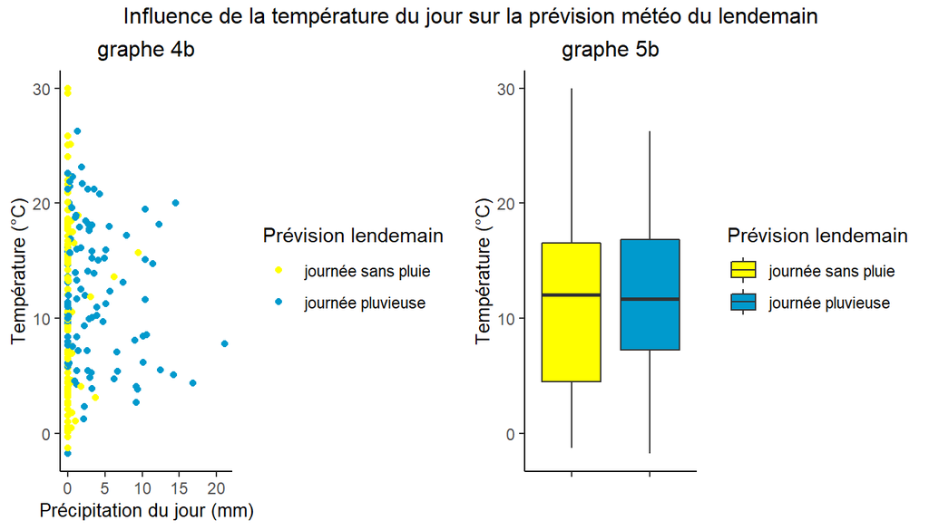

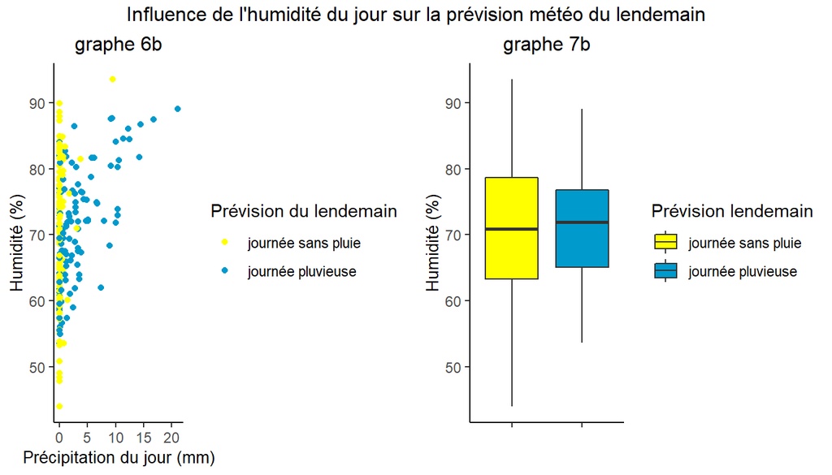

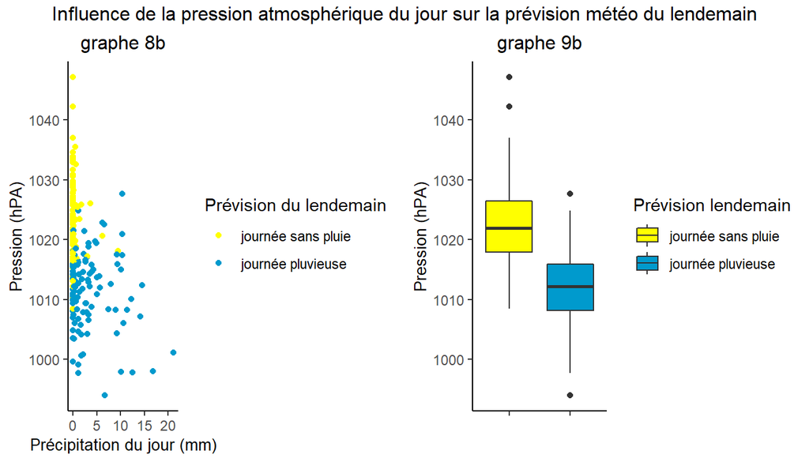

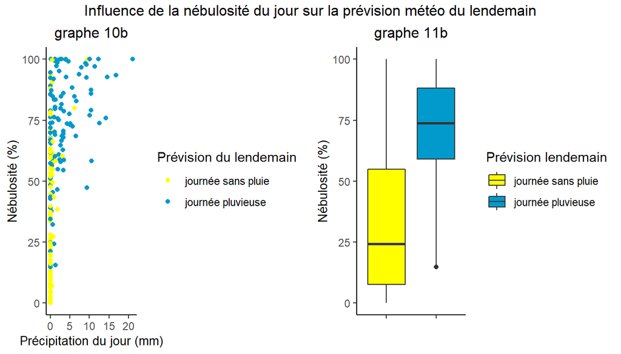

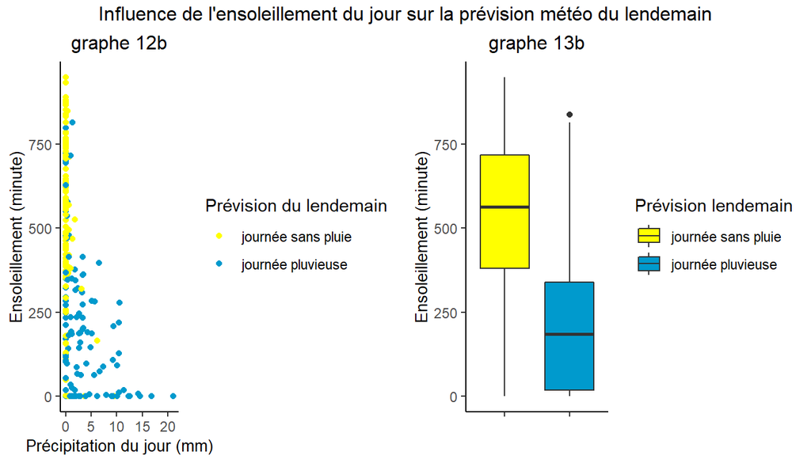

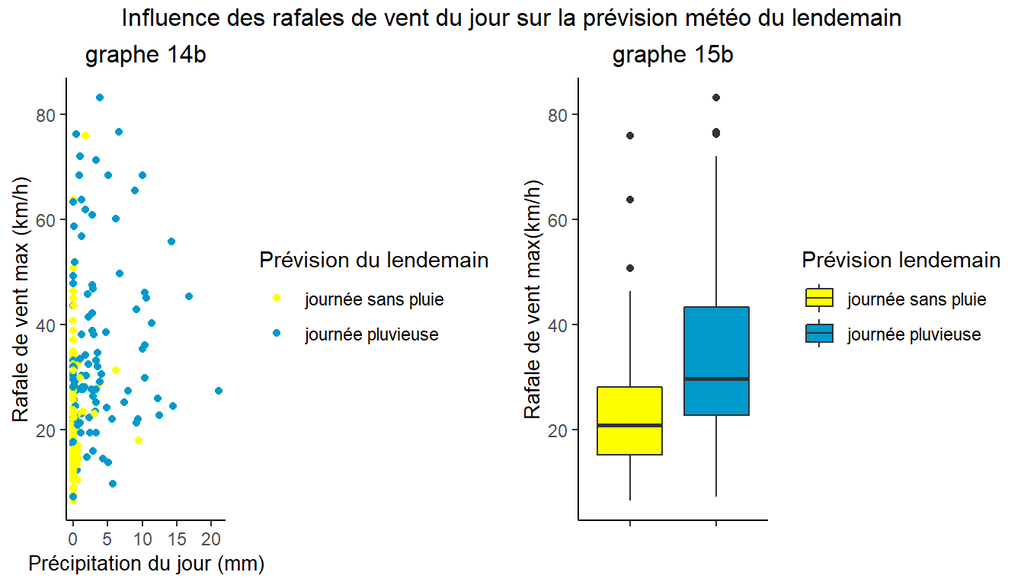

# 6 Les bords du Rhin à Bâle au soleil et sous la pluie …

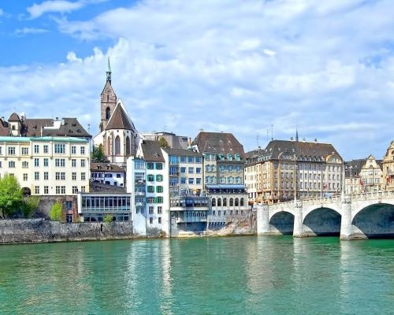

[figure not shown]